# Fitting the separate-means model in R

Yanming Di

03 March, 2019

# Getting started

I highly recommend you download the free R studio. If you have question regarding R, please come to my office hours!

First, you want plan where to put your R codes and the data sets. In my case, I created two folders

- data
- R

The data sets are in the folder data and my R codes in the folder R.

# Background

BP0—a small subset of the data from a clinical trial of an antihypertensive (blood-pressure-lowering) drug, for use in class illustrations. Each line represents a person who was randomly assigned to one of three dose groups and treated for six weeks.

DOSE dose of the drug, in arbitrary units (0 = placebo)

CHANGE change in diastolic blood pressure (final minus initial), in mm Hg

# Load data into R

The following line will use the function “read.table” to load the data file into R, create a “dataframe”, and assign it to the variable “bp0”:

```r
bp0 <- read.table("../data/bp0.txt",header=T)
```

A dataframe (matrix-like data structure) is the basic data structure in R. You can see the data structure more clearly using the function “str”

```r
str(bp0)
```

```
## 'data.frame':    15 obs. of  2 variables:
##  $ dose  : int  0 0 0 0 0 20 20 20 20 20 ...
##  $ change: int  14 6 5 -3 -7 1 0 -4 -5 -13 ...
```

It says “bp0” has two lists of integers (note that, later, we want to treat “dose” as factor levels rather than integers.)

# Look at data:

Look at the first few observations:

```r
head(bp0)                                # same as typing 'bp0[1:6,]').
```

```
##   dose change
## 1    0     14
## 2    0      6
## 3    0      5
## 4    0     -3
## 5    0     -7
## 6   20      1
```

Attach the data frame (so we can access its columns directly):

```r
attach(bp0)
```

Two ways to draw side-by-side boxplots (I like the second version)

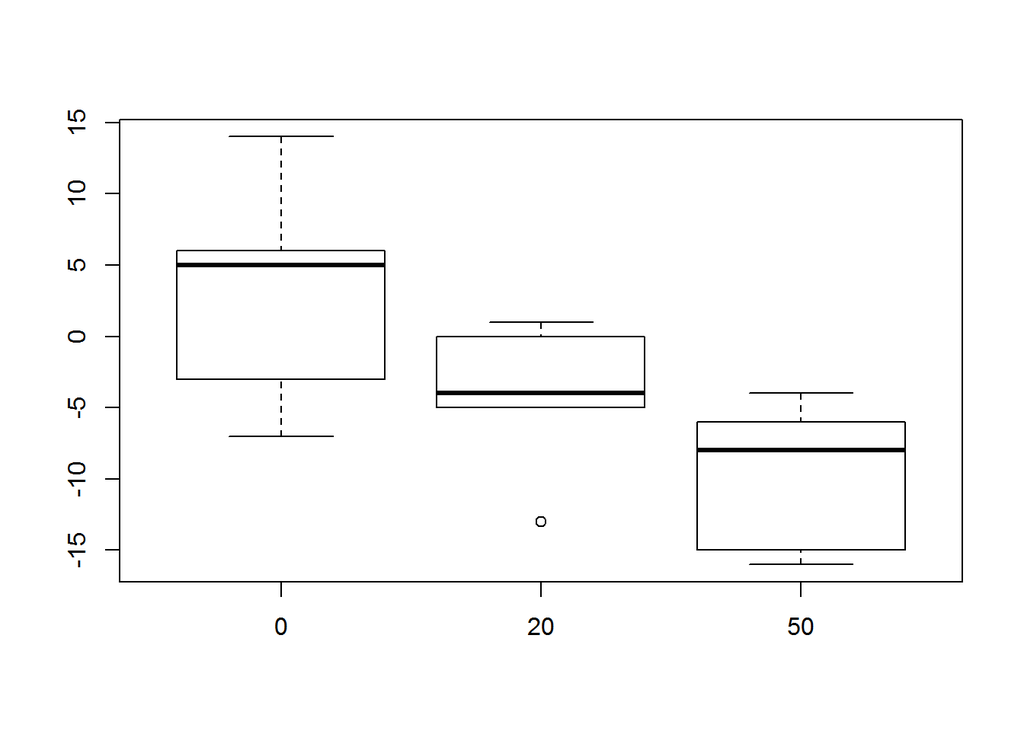

```r
boxplot(split(change, dose))            # Boxplot of change by dose.
```

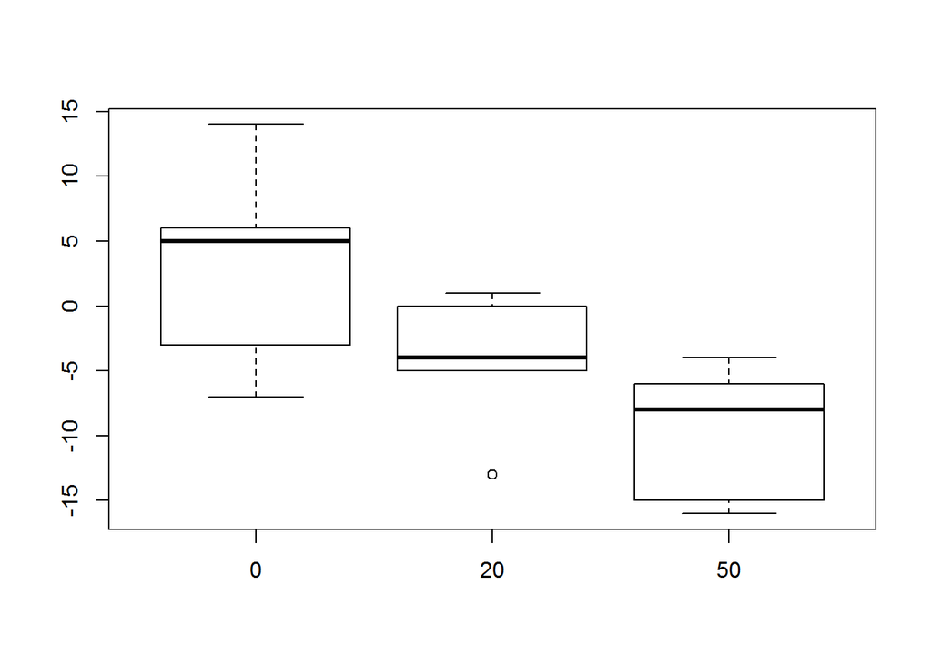

```r
boxplot(change ~ dose)
```

## Fit a linear regression model

```r
dose.f <- as.factor(dose)               # Create a categorical version
                                        # of dose.
sm <- lm(change ~ dose.f)              # Fit the separate-means model.
```

See the model matrix,

```r
model.matrix(sm);
```

```
##    (Intercept) dose.f20 dose.f50
## 1            1        0        0
## 2            1        0        0
## 3            1        0        0
## 4            1        0        0
## 5            1        0        0
## 6            1        1        0
## 7            1        1        0
## 8            1        1        0
## 9            1        1        0
## 10           1        1        0
## 11           1        0        1
## 12           1        0        1
## 13           1        0        1
## 14           1        0        1
## 15           1        0        1
## attr(,"assign")
## [1] 0 1 1
## attr(,"contrasts")
## attr(,"contrasts")$dose.f
## [1] "contr.treatment"
```

Can you see the correspondence between this parameterization and the parameteriztion discussed in the lecture notes?

## ANOVA

```r
anova(sm)                              # Get the ANOVA table.
```

```
## Analysis of Variance Table
##
## Response: change
##           Df Sum Sq Mean Sq F value  Pr(>F)
## dose.f     2 411.73 205.867  4.8477 0.02863 *
## Residuals 12 509.60  42.467
## ---
## Signif. codes:  0 '***' 0.001 '**' 0.01 '*' 0.05 '.' 0.1 ' ' 1
```

```r
1 - pf(4.8477, 2, 12)                  # See where the P-value comes from.
```

```
## [1] 0.02863397
```

## Test mean differences

It’s a bit tricky to extract the MSE from the ANOVA output: in this case it is the second mean squares term in the ANOVA output

```r
a =  anova(sm);
mse = a$`Mean Sq`[2];
df = a$Df[2];
```

Compute group means:

```r
## Group sizes
r = tapply(change, dose,length);

## Group means
m = tapply(change, dose, mean);
```

Compute the $t$-statistic for comparing mean difference between group 1 and 2:

```r
## Compute the standard error:
se = sqrt(mse/r[1] + mse/r[2]);

## Compute the t-statistic
t = (m[2] - m[1])/se;

## Compute the p-value, compare the t-statistic to a t-distribution
p = pt(abs(t), df, lower.tail=FALSE) * 2;

##
cat(sprintf("t=%.3f, p=%.3f\n", t, p));
```

```
## t=-1.747, p=0.106
```

## General contrast of the means

Suppose, we want to compare the average reduction in the does 20 and does 50 groups to that of the does 0 group:

```r
## The MSE and its df is the same as above.

## Specify the coefficients of the contrast, the contrast will then be
##     k1 mu1 + k2 mu2 + k3 mu3
k = c(-1, 1/2, 1/2);

## Compute the standard error of the contrast
se = sqrt(mse * sum(k^2/r));

## Compute the t-statistic and p-value
t = sum (k * m)/se;

p = pt(abs(t), df, lower.tail=FALSE) * 2;

cat(sprintf("t=%.3f, p=%.3f\n", t, p));
```

```
## t=-2.802, p=0.016
```

We conclude that there is moderate/strong evidence ($p=0.016$) that the average reduction in blood pressure from groups with doses 20 and 50 are significantly greater than that from group with dose 0.

## Welch’s one-way test

Welch’s one-way test does not assume constant variance (of the errors). Note the difference in the denominator degrees of freedom in this test (we need to estimate three variances instead of one).

```r
oneway.test(change ~ dose.f)
```

```
##
##  One-way analysis of means (not assuming equal variances)
##
## data:  change and dose.f
## F = 4.0378, num df = 2.0000, denom df = 7.7965, p-value = 0.06259
```

## Kruskal-Willis test

```r
kruskal.test(change~dose);
```

```
##
##  Kruskal-Wallis rank sum test
##
## data:  change by dose
## Kruskal-Wallis chi-squared = 6.3463, df = 2, p-value = 0.04187
```

## Regression output

```r
summary(sm)                           # Get regression output.
```

```
##
## Call:
## lm(formula = change ~ dose.f)
##
## Residuals:
##    Min     1Q Median     3Q    Max
##  -10.0   -5.6    1.8    4.0   11.0
##
## Coefficients:
##             Estimate Std. Error t value Pr(>|t|)
## (Intercept)    3.000      2.914   1.029  0.32360
## dose.f20      -7.200      4.121  -1.747  0.10617
## dose.f50     -12.800      4.121  -3.106  0.00909 **
## ---
## Signif. codes:  0 '***' 0.001 '**' 0.01 '*' 0.05 '.' 0.1 ' ' 1
##
## Residual standard error: 6.517 on 12 degrees of freedom
## Multiple R-squared:  0.4469, Adjusted R-squared:  0.3547
## F-statistic: 4.848 on 2 and 12 DF,  p-value: 0.02863
```

The intercept is the mean change in the zero-dose group. Each of the other coefficients is the difference in response between that group and the zero-dose group.

```r
mean(change[dose.f==0])                # the intercept, beta0-hat
```

```
## [1] 3
```

```r
mean(change[dose.f==20])
```

```
## [1] -4.2
```

Note the relationship between the residual standard error (RSE) from the regression output and the mean square error (MSE) from the ANOVA output: MSE = RSE^2

```r
6.517^2
```

```
## [1] 42.47129
```

## Power and sample size calculations

### ANOVA test

Suppose the mean levels are as estimated values and the variance of the random errors is $6.517^2$ (as estimated from the regression model). What is the power of the ANOVA F-test for group means, assuming the significance level is 0.05?

```r
m = c(3, -4.2, -9.8);
v = 6.517^2;
power.anova.test(groups = 3, n = 5, between.var = var(m), within.var=v, sig.level = 0.05)
```

```
##
##      Balanced one-way analysis of variance power calculation
##
##          groups = 3
##               n = 5
##     between.var = 41.17333
##      within.var = 42.47129
##       sig.level = 0.05
##           power = 0.6872421
##
## NOTE: n is number in each group
```

What is the sample size needed to achieve 90% power to detect such differences in an ANOVA test?

```r
power.anova.test(groups = 3, between.var = var(m), within.var=v, power=0.90)
```

```
##
##      Balanced one-way analysis of variance power calculation
##
##          groups = 3
##               n = 7.628425
##     between.var = 41.17333
##      within.var = 42.47129
##       sig.level = 0.05
##           power = 0.9
##
## NOTE: n is number in each group
```

### Two-sample t-test

Suppose we want to compare the difference beteween the first two groups using a two-sample t-test, what is the power of our test?

```r
delta = (-4.2) - 3;
alpha = 0.05;
power.t.test(n = 5, delta = delta, sd = 6.517, sig.level=alpha);
```

```
##
##      Two-sample t test power calculation
##
##               n = 5
##           delta = 7.2
##              sd = 6.517
##       sig.level = 0.05
##           power = 0.3370999
##     alternative = two.sided
##
## NOTE: n is number in *each* group
```

What is the sample size (in each group) needed to archieve a power of 80%:

```r
power.t.test(delta = delta, sd = 6.517, sig.level=alpha, power=0.80);
```

```
##
##      Two-sample t test power calculation
##
##               n = 13.88996
##           delta = 7.2
##              sd = 6.517
##       sig.level = 0.05
##           power = 0.8
##     alternative = two.sided
##
## NOTE: n is number in *each* group
```

Sample size calculation using the formula on page 20 of the notes:

```r
delta = (-4.2) - 3;
alpha = 0.05;
power = 0.8;
z0 = qnorm(1-alpha/2); # This z_(alpha/2)
z1 = qnorm(power); # This is z_beta, since (1-beta) = power.
v = 6.517^2;
n = 2 * v * (z1 + z0)^2/delta^2;
n
```

```
## [1] 12.8608
```

## Diagnostics

```r
## Fitted values and residuals from the fitted model
y.hat = fitted(sm);
r = residuals(sm);
all.equal(r, change-y.hat)
```

```
## [1] TRUE
```

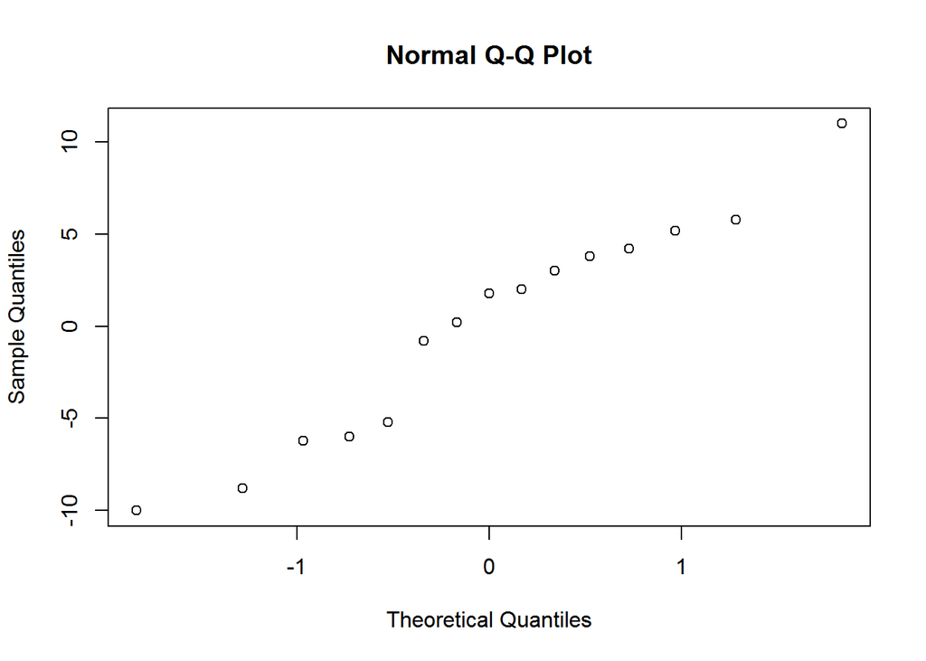

```r
## Normal qqplot for the residuals
qqnorm(r);
```

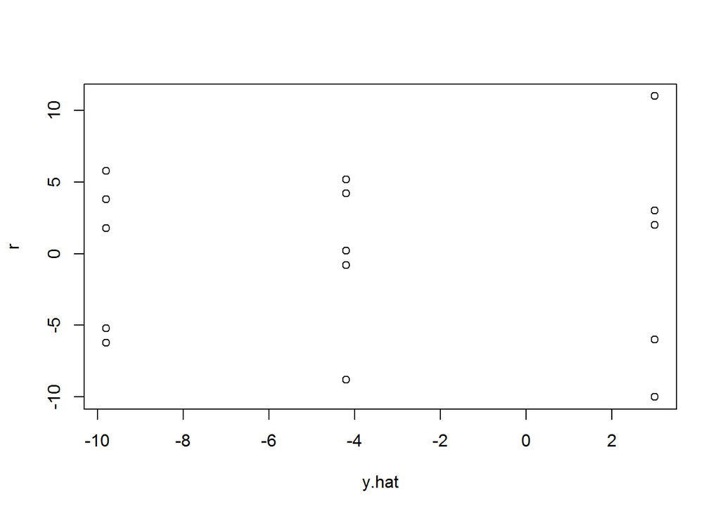

```r
## Residual plot
plot(y.hat, r)
```

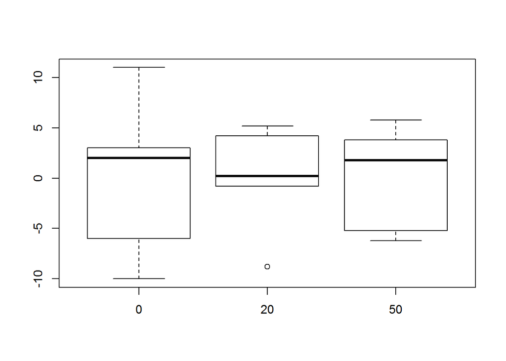

```r
## Boxplot by treatment group
boxplot(r~dose)
```

```r
## levene.test(r ~ dose)
source('levene2.R');
levene2(r, dose, method=2)
```

```
## Analysis of Variance Table
##
## Response: z
##           Df  Sum Sq Mean Sq F value Pr(>F)
## group      2  13.733  6.8667  0.4008 0.6784
## Residuals 12 205.600 17.1333
##
## P-value for testing equality of variances of y's = 0.6784
```

```r
## In this example, Levene test for the residuals is equivalent to Levene test for the observed values
levene2(change, dose, method=2)
```

```
## Analysis of Variance Table
##
## Response: z
##           Df  Sum Sq Mean Sq F value Pr(>F)
## group      2  13.733  6.8667  0.4008 0.6784
## Residuals 12 205.600 17.1333
##
## P-value for testing equality of variances of y's = 0.6784
```

```r
## Studendized residuals
rstandard(sm);
```

```
##           1           2           3           4           5           6
##  1.88722467  0.51469764  0.34313176 -1.02939527 -1.71565879  0.89214257
##           7           8           9          10          11          12
##  0.72057669  0.03431318 -0.13725270 -1.50977974  0.99508210  0.65195034
##          13          14          15
##  0.30881858 -0.89214257 -1.06370845
```

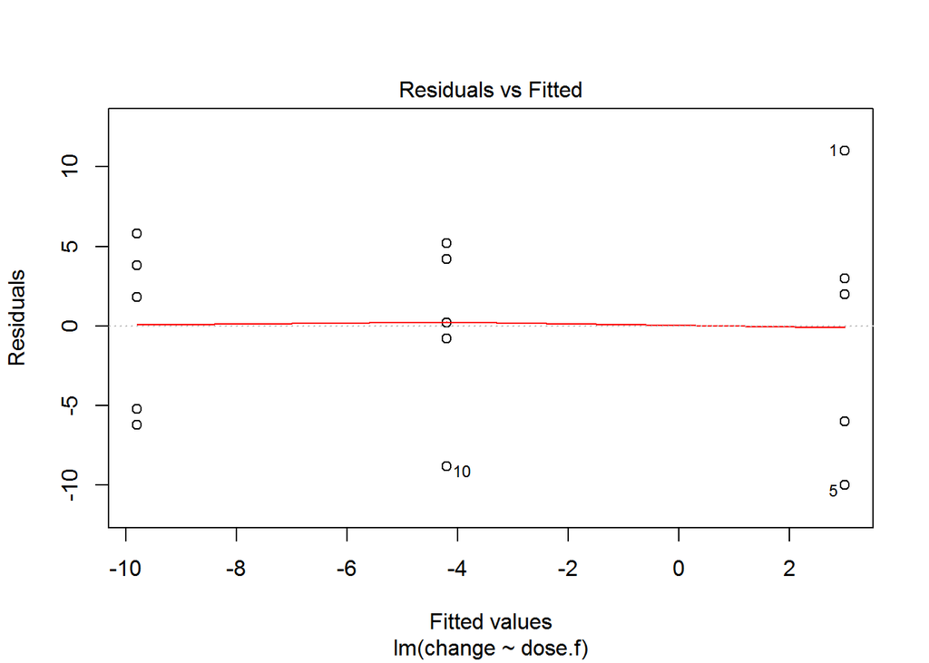

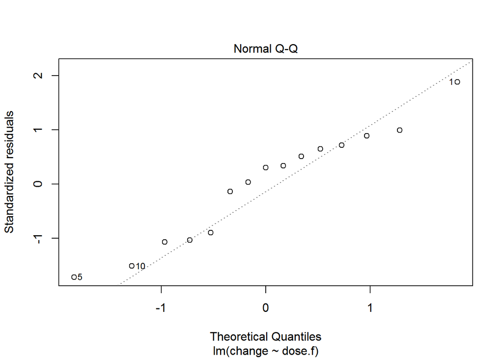

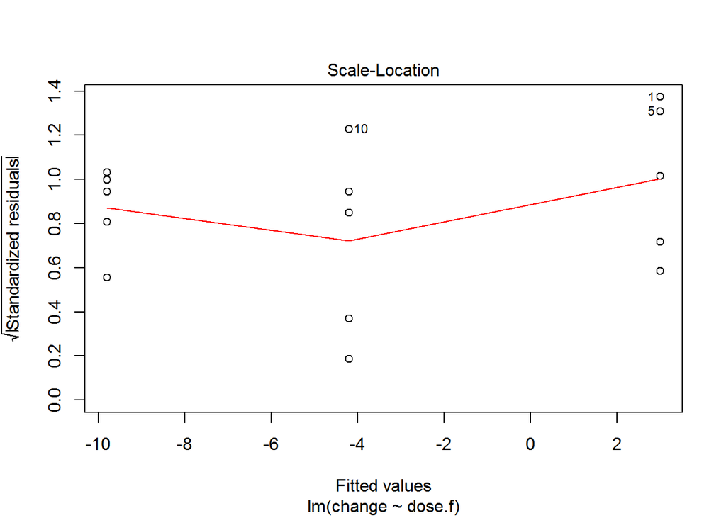

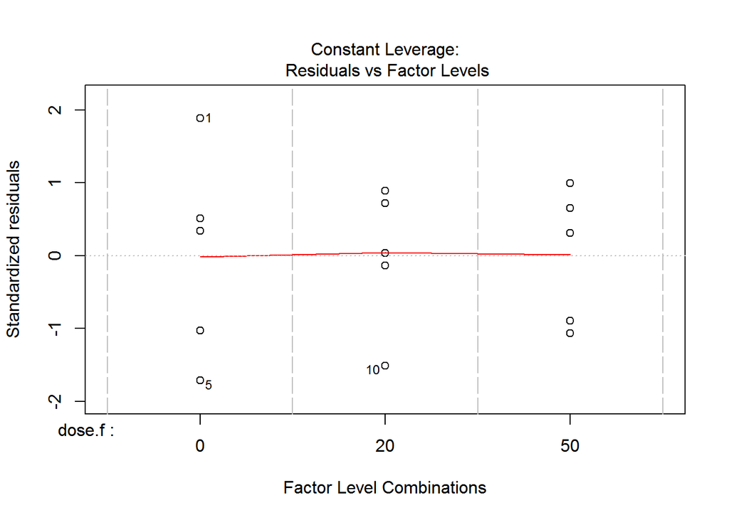

```r
## If you plot the fitted linear regression model, it will give you the above plots and more
plot(sm)
```

```r
detach(bp0)
```